# Análisis del crimen en L.A. con H2O

Santiago Mota (santiago_mota@yahoo.es)

2018-03-13

## Análisis del crimen en L.A. con H2O

Primero, las librerías

```r
# Para cada librería preguntamos primero si está instalada
if(!is.element("dplyr", installed.packages()[, 1]))
      install.packages("dplyr", repos = 'http://cran.us.r-project.org')
library(dplyr)
if(!is.element("ggplot2", installed.packages()[, 1]))
      install.packages("ggplot2", repos = 'http://cran.us.r-project.org')
library(ggplot2)
if(!is.element("lubridate", installed.packages()[, 1]))
      install.packages("lubridate", repos = 'http://cran.us.r-project.org')
library(lubridate)
if(!is.element("chron", installed.packages()[, 1]))
      install.packages("chron", repos = 'http://cran.us.r-project.org')
library(chron)
if(!is.element("pROC", installed.packages()[, 1]))
      install.packages("pROC", repos = 'http://cran.us.r-project.org')
library(pROC)
```

La de H2O la tratamos aparte. Si hay que instalarla o actualizarla, es mejor descargarla desde su cuenta de AWS

```r
# http://h2o-release.s3.amazonaws.com/h2o/rel-wolpert/2/index.html
# The following two commands remove any previously installed H2O packages for R.
if ("package:h2o" %in% search()) { detach("package:h2o", unload=TRUE) }
if ("h2o" %in% rownames(installed.packages())) { remove.packages("h2o") }

# Next, we download packages that H2O depends on.
pkgs <- c("RCurl","jsonlite")
for (pkg in pkgs) {
if (! (pkg %in% rownames(installed.packages()))) { install.packages(pkg) }
}

# Now we download, install and initialize the H2O package for R.
install.packages("h2o", type="source", repos="http://h2o-release.s3.amazonaws.com/h2o/rel-wolpert/2/R")
```

Ahora ya podemos cargar el paquete

```r
library(h2o)
```

Obtenemos los datos de la [web](https://data.lacity.org/A-Safe-City/Crime-Data-from-2010-to-Present/y8tr-7khq/data): https://data.lacity.org/A-Safe-City/Crime-Data-from-2010-to-Present/y8tr-7khq/data en la pestaña **export** y en **download as** elegimos el formato **csv**

Cargamos los datos (acordándonos de modificar la ruta)

```r
# Datos descargados el 15-02-2018
crime_data <- read.csv('/media/enero/Disco1/Varios/R/Archivos/clases_r/h2o/data/Crime_Data_from_2010_to_Present-15-02-2018.csv')
```

Un **summary()**

```r
summary(crime_data)
```

```
##    DR.Number            Date.Reported        Date.Occurred
##  Min.   :      210   08/07/2017:    805   01/01/2010:   2155
##  1st Qu.:120315238   12/18/2017:    794   01/01/2011:   2069
##  Median :140620602   07/24/2017:    783   01/01/2012:   1664
##  Mean   :138030952   10/23/2017:    771   01/01/2013:   1489
##  3rd Qu.:160624731   11/28/2017:    762   01/01/2014:   1353
##  Max.   :910220366   01/29/2018:    761   01/01/2015:   1301
##                      (Other)   :1678633   (Other)   :1673278
##  Time.Occurred     Area.ID            Area.Name       Reporting.District
##  Min.   :   1   Min.   : 1.00   77th Street: 117154   Min.   : 100
##  1st Qu.: 930   1st Qu.: 6.00   Southwest  : 108517   1st Qu.: 645
##  Median :1430   Median :12.00   N Hollywood:  91554   Median :1204
##  Mean   :1364   Mean   :11.14   Pacific    :  88964   Mean   :1161
##  3rd Qu.:1900   3rd Qu.:16.00   Southeast  :  88578   3rd Qu.:1675
##  Max.   :2359   Max.   :21.00   Mission    :  84802   Max.   :2198
##                                 (Other)    :1103740
##    Crime.Code                           Crime.Code.Description
##  Min.   :110.0   BATTERY - SIMPLE ASSAULT          :154114
##  1st Qu.:330.0   BURGLARY FROM VEHICLE             :129308
##  Median :440.0   VEHICLE - STOLEN                  :129271
##  Mean   :506.8   BURGLARY                          :121439
##  3rd Qu.:626.0   THEFT PLAIN - PETTY ($950 & UNDER):120106
##  Max.   :956.0   THEFT OF IDENTITY                 :105852
##                  (Other)                           :923219
##     MO.Codes         Victim.Age     Victim.Sex Victim.Descent
##         : 182688   Min.   :10.00     :155068   H      :582840
##  0344   : 182670   1st Qu.:23.00    -:     1   W      :414424
##  0329   :  72917   Median :34.00    F:715645   B      :269782
##  1501   :  36281   Mean   :35.97    H:    56   O      :162664
##  0416   :  25262   3rd Qu.:48.00    M:784098          :155104
##  0325   :  22698   Max.   :99.00    X: 28441   X      : 47013
##  (Other):1160793   NA's   :135446              (Other): 51482
##   Premise.Code                                   Premise.Description
##  Min.   :101   STREET                                      :375205
##  1st Qu.:102   SINGLE FAMILY DWELLING                      :346791
##  Median :210   MULTI-UNIT DWELLING (APARTMENT, DUPLEX, ETC):216227
##  Mean   :312   PARKING LOT                                 :119893
##  3rd Qu.:501   SIDEWALK                                    : 84044
##  Max.   :971   OTHER BUSINESS                              : 75323
##  NA's   :97    (Other)                                     :465826
```

[output cut: 33 more lines]

```
##  6TH                          ST        :   3897
##  7TH                          ST        :   3014
##  9300    TAMPA                        AV:   2873
##  5TH                          ST        :   2415
##  6TH                                    :   2409
##  6600    TOPANGA CANYON               BL:   2340
##  (Other)                                :1666361
##                           Cross.Street                     Location
##                                 :1403492   (0, 0)              :   6416
##  BROADWAY                       :   4923   (34.1016, -118.3387):   3192
##  FIGUEROA                       :   2969   (34.1905, -118.6059):   2316
##  VERMONT                      AV:   2953   (33.9892, -118.3089):   2001
##  SAN PEDRO                      :   2821   (34.1576, -118.438) :   1797
##  WESTERN                      AV:   2821   (34.2216, -118.4488):   1684
##  (Other)                        : 263330   (Other)             :1665903
```

Y un **str()**

```r
str(crime_data)
```

```
## 'data.frame':    1683309 obs. of  26 variables:
##  $ DR.Number             : int  1208575 102005556 418 101822289 42104479 120125367 101105609 101620051 101910498 120908292 ...
##  $ Date.Reported         : Factor w/ 2963 levels "01/01/2010","01/01/2011",..: 623 217 663 2556 95 67 244 2556 812 743 ...
##  $ Date.Occurred         : Factor w/ 2963 levels "01/01/2010","01/01/2011",..: 599 190 655 2548 32 67 235 2524 812 130 ...
##  $ Time.Occurred         : int  1800 2300 2030 1800 2300 1400 2230 1600 1600 800 ...
##  $ Area.ID               : int  12 20 18 18 21 1 11 16 19 9 ...
##  $ Area.Name             : Factor w/ 21 levels "77th Street",..: 1 12 15 15 17 2 11 4 8 18 ...
##  $ Reporting.District    : int  1241 2071 1823 1803 2133 111 1125 1641 1902 904 ...
##  $ Crime.Code            : int  626 510 510 510 745 110 510 510 510 668 ...
##  $ Crime.Code.Description: Factor w/ 143 levels "","ABORTION/ILLEGAL",..: 76 139 139 139 137 40 139 139 139 59 ...
##  $ MO.Codes              : Factor w/ 370891 levels "","0100","0100 0104",..: 168286 1 1 1 48103 264208 1 1 1 107446 ...
##  $ Victim.Age            : int  30 NA 12 NA 84 49 NA NA NA 27 ...
##  $ Victim.Sex            : Factor w/ 6 levels "","-","F","H",..: 3 1 1 1 5 3 1 1 1 3 ...
##  $ Victim.Descent        : Factor w/ 21 levels "","-","A","B",..: 19 1 1 1 19 19 1 1 1 14 ...
##  $ Premise.Code          : int  502 101 101 101 501 501 108 101 101 203 ...
##  $ Premise.Description   : Factor w/ 304 levels "","7TH AND METRO CENTER (NOT LINE SPECIFIC)",..: 193 261 261 261 250 250 214 261 261 206 ...
##  $ Weapon.Used.Code      : int  400 NA NA NA NA 400 NA NA NA NA ...
##  $ Weapon.Description    : Factor w/ 80 levels "","AIR PISTOL/REVOLVER/RIFLE/BB GUN",..: 67 1 1 1 1 67 1 1 1 1 ...
##  $ Status.Code           : Factor w/ 10 levels "","13","19","AA",..: 5 7 7 7 7 4 7 7 7 7 ...
##  $ Status.Description    : Factor w/ 6 levels "Adult Arrest",..: 2 3 3 3 3 1 3 3 3 3 ...
##  $ Crime.Code.1          : int  626 510 510 510 745 110 510 510 510 668 ...
##  $ Crime.Code.2          : int  NA NA NA NA NA NA NA NA NA NA ...
##  $ Crime.Code.3          : int  NA NA NA NA NA NA NA NA NA NA ...
##  $ Crime.Code.4          : int  NA NA NA NA NA NA NA NA NA NA ...
##  $ Address               : Factor w/ 71796 levels "00","00000    20TH                         AV",..: 49292 70835 25051 58794 53019 48048 71755 64955 65708 53176 ...
##  $ Cross.Street          : Factor w/ 11487 levels "","100TH                        ST",..: 1 139 1 10697 1 1 1121 10158 3362 1 ...
##  $ Location              : Factor w/ 61121 levels "","(0, 0)","(33.3427, -118.3258)",..: 9181 20839 4882 6203 45655 24053 34484 52498 60520 45810 ...
```

Es un dataset grande, de mas de 1,5 millones de observaciones

## Cambio de nombre de las variables

Vemos los nombres

```r
names(crime_data)
```

```
##  [1] "DR.Number"              "Date.Reported"
##  [3] "Date.Occurred"          "Time.Occurred"
##  [5] "Area.ID"                "Area.Name"
##  [7] "Reporting.District"     "Crime.Code"
##  [9] "Crime.Code.Description" "MO.Codes"
## [11] "Victim.Age"             "Victim.Sex"
## [13] "Victim.Descent"         "Premise.Code"
## [15] "Premise.Description"    "Weapon.Used.Code"
## [17] "Weapon.Description"     "Status.Code"
## [19] "Status.Description"     "Crime.Code.1"
## [21] "Crime.Code.2"           "Crime.Code.3"
## [23] "Crime.Code.4"           "Address"
## [25] "Cross.Street"           "Location"
```

Vamos a cambiarlas

```r
# Minusculas
names(crime_data) <- tolower(names(crime_data))

# cambiar . por _
names(crime_data) <- gsub('.', '_', names(crime_data), fixed = TRUE)

# Las vemos
names(crime_data)
```

```
##  [1] "dr_number"              "date_reported"
##  [3] "date_occurred"          "time_occurred"
##  [5] "area_id"                "area_name"
##  [7] "reporting_district"     "crime_code"
##  [9] "crime_code_description" "mo_codes"
## [11] "victim_age"             "victim_sex"
## [13] "victim_descent"         "premise_code"
## [15] "premise_description"    "weapon_used_code"
## [17] "weapon_description"     "status_code"
## [19] "status_description"     "crime_code_1"
## [21] "crime_code_2"           "crime_code_3"
## [23] "crime_code_4"           "address"
## [25] "cross_street"           "location"
```

## Análisis de NAs

Algunos cambios en valores para pasarlos a NA

### Mo Codes

```r
# Los pasamos a caracter
crime_data$mo_codes <- as.character(crime_data$mo_codes)

# Cambiamos los valores en blanco por NA
crime_data$mo_codes[crime_data$mo_codes==''] <- NA

# table(crime_data$mo_code, useNA = 'ifany') # Ocupa mucho
```

Creamos un objeto con los valores únicos

```r
# Los valores únicos de crime_data$mo_codes
mo_codes <- unique(as.character(crime_data$mo_codes))

# Quitamos los NAs
mo_codes <- mo_codes[!is.na(mo_codes)]
```

```r
# Sacamos los valores únicos
mo_codes_unique <- unique(paste(mo_codes, collapse = ' '))

# Separamos los valores con ' '
mo_codes <- unique(strsplit(mo_codes_unique, ' '))

# Pasamos a character
mo_codes <- unlist(mo_codes)

# Nos quedamos con los valores únicos
mo_codes <- unique(mo_codes)

# Los ordenamos
mo_codes <- mo_codes[order(mo_codes)]

# Cuantos hay
length(mo_codes)
```

```
## [1] 674
```

Aquí podríamos obtener un one-hot-encoding de los mo_codes. No lo hacemos porque estamos evaluando la eficacia de autoML, pero es uno de los temas a tratar para mejorar el modelado

### Status codes

```r
# Los pasamos a caracter
crime_data$status_code <- as.character(crime_data$status_code)

# Cambiamos los valores en blanco por NA
crime_data$status_code[crime_data$status_code==''] <- NA

# Volvemos a pasar a factor
crime_data$status_code <- as.factor(crime_data$status_code)

# Sacamos una tabla
table(crime_data$status_code, useNA = 'ifany')
```

```
##
##      13      19      AA      AO      CC      IC      JA      JO      TH
##       1       1  172666  190613      26 1302599   13246    4154       1
##    <NA>
##       2
```

### Cross Street

```r
# Pasamos a caracter
crime_data$cross_street <- as.character(crime_data$cross_street)

# Cambiamos los valores en blanco por NA
crime_data$cross_street[crime_data$cross_street %in% c('')] <- NA

# table(crime_data$cross_street, useNA = 'ifany')  # Muy largo

# Volvemos a pasar a factor
crime_data$cross_street <- as.factor(crime_data$cross_street)
```

### Weapon description

```r
# Pasamos a caracter
crime_data$weapon_description <- as.character(crime_data$weapon_description)

# Cambiamos los valores en blanco por NA
crime_data$weapon_description[crime_data$weapon_description %in% c('')] <- NA

# table(crime_data$weapon_description, useNA = 'ifany')  # Muy largo

# Volvemos a pasar a factor
crime_data$weapon_description <- as.factor(crime_data$weapon_description)
```

### Crime code description

```r
crime_data$crime_code_description <- as.character(crime_data$crime_code_description)


crime_data$crime_code_description[crime_data$crime_code_description %in% c('')] <- NA

# table(crime_data$crime_code_description, useNA = 'ifany')

# Volvemos a pasar a factor
crime_data$crime_code_description <- as.factor(crime_data$cross_street)
```

### Premise description

```r
# Pasamos a caracter
crime_data$premise_description <- as.character(crime_data$premise_description)

# Cambiamos los valores en blanco por NA
crime_data$premise_description[crime_data$premise_description %in% c('')] <- NA

# table(crime_data$premise_description, useNA = 'ifany')

# Volvemos a pasar a factor
crime_data$premise_description <- as.factor(crime_data$premise_description)
```

### Address

```r
# Pasamos a caracter
crime_data$address <- as.character(crime_data$address)

# Cambiamos los valores '00' por NA
crime_data$address[crime_data$address=='00'] <- NA

# table(crime_data$address, useNA = 'ifany')

# Pasamos a factor
crime_data$address <- as.factor(crime_data$address)
```

### Sex

```r
# Pasamos a caracter
crime_data$victim_sex <- as.character(crime_data$victim_sex)

# Cambiamos los valores en blanco y los '-' por NA
crime_data$victim_sex[crime_data$victim_sex %in% c('', '-')] <- NA

# Una tabla
table(crime_data$victim_sex, useNA = 'ifany')
```

```
##
##      F      H      M      X   <NA>
## 715645     56 784098  28441 155069
```

```r
# Volvemos a pasar a factor
crime_data$victim_sex <- as.factor(crime_data$victim_sex)
```

### Descent Code

A - Other Asian B - Black C - Chinese D - Cambodian F - Filipino G - Guamanian H - Hispanic/Latin/Mexican I - American Indian/Alaskan Native J - Japanese K - Korean L - Laotian O - Other P - Pacific Islander S - Samoan U - Hawaiian V - Vietnamese W - White X - Unknown Z - Asian Indian

```r
# Renombramos los niveles
levels(crime_data$victim_descent) <- c("", "-", " Other_Asian", "Black",
                                       "Chinese", "Cambodian", "Filipino",
                                       "Guamanian", "Hispanic-Latin-Mexican",
                                       "American_Indian-Alaskan_Native",
                                       "Japanese", "Korean", "Laotian", "Other",
                                       "Pacific_Islander", "Samoan",
                                       "Hawaiian", "Vietnamese", "White",
                                       "Unknown", "Asian_Indian")
# Pasamos a caracter
crime_data$victim_descent <- as.character(crime_data$victim_descent)

# Cambiamos los valores en blanco y los '-' por 'Unknown'
crime_data$victim_descent[crime_data$victim_descent %in% c('', '-')] <- 'Unknown'

# Una tabla
table(crime_data$victim_descent, useNA = 'ifany')
```

```
##
## American_Indian-Alaskan_Native                   Asian_Indian
##                            711                             58
##                          Black                      Cambodian
##                         269782                             15
##                        Chinese                       Filipino
##                            645                           1981
##                      Guamanian                       Hawaiian
##                             69                            156
##         Hispanic-Latin-Mexican                       Japanese
##                         582840                            248
##                         Korean                        Laotian
##                           7531                             10
##                          Other                    Other_Asian
##                         162664                          39648
##               Pacific_Islander                         Samoan
##                            292                             26
##                        Unknown                     Vietnamese
##                         202118                             91
##                          White
##                         414424
```

```r
# Y volvemos a factor
crime_data$victim_descent <- as.factor(crime_data$victim_descent)
```

### Location

```r
# pasamos a caracter
crime_data$location <- as.character(crime_data$location)

# Los que tienen location '' los pasamos a '(0, 0)'
crime_data$location[crime_data$location==""] <- "(0, 0)"

# table(crime_data$location, useNA = 'ifany')
```

Creamos un objeto (crime_data_location) y limpiamos crime_data_location, quitando ‘’, ‘(’ y ‘)’

```r
# Copiamos de crime_data$location
crime_data_location <- crime_data$location

# Quitamos los '('
crime_data_location <- gsub('(', '', crime_data_location, fixed = TRUE)

# Quitamos los ')'
crime_data_location <- gsub(')', '', crime_data_location, fixed = TRUE)

# Quitamos los ' '
crime_data_location <- gsub(' ', '', crime_data_location, fixed = TRUE)
```

```r
temp2 <- strsplit(crime_data_location, ',')
# temp3 <- as.data.frame(temp2)
temp4 <- unlist(temp2)
temp5 <- stringr::str_split(crime_data_location, ',')
# temp6 <- as.data.frame(temp5, optional = TRUE)

# https://stackoverflow.com/questions/4227223/r-list-to-data-frame
temp7 <- do.call(rbind.data.frame, temp2)
# temp8 <- do.call(rbind, lapply(temp2, data.frame, stringsAsFactors=FALSE))
# temp9 <- do.call(rbind, lapply(temp2, matrix, stringsAsFactors=FALSE))
temp10 <- data.frame(matrix(unlist(temp2), nrow=1674208, byrow=T),
                     stringsAsFactors=FALSE)
```

Vamos a incluir en **crime_data** las variables location_x y location_y

```r
# https://stackoverflow.com/questions/4227223/r-list-to-data-frame
crime_data_location_df <- data.frame(matrix(unlist(strsplit(crime_data_location, ',')),
                                            nrow=length(crime_data_location),
                                            byrow=T), stringsAsFactors=FALSE)

# Cambiamos los nombres
names(crime_data_location_df) <- c('location_x', 'location_y')

# Pasamos a numérico
crime_data$location_x <- as.numeric(crime_data_location_df$location_x)
crime_data$location_y <- as.numeric(crime_data_location_df$location_y)

# Cambiamos los 0 por NAs
crime_data$location_x[crime_data$location_x==0] <- NA
crime_data$location_y[crime_data$location_y==0] <- NA

# Cambiamos también los (0, 0) por NAs
crime_data$location[crime_data$location=="(0, 0)"] <- NA

# Y pasamos location a factor (ya tenemos un location_x y location_y numericos)
crime_data$location <- as.factor(crime_data$location)
```

Limpiamos el entorno

```r
# Borramos dos datasets
rm(crime_data_location_df, crime_data_location)

# Limpiamos y vemos la memoria
gc()
```

```
##            used  (Mb) gc trigger  (Mb) max used  (Mb)
## Ncells  1314514  70.3    3886542 207.6  3409184 182.1
## Vcells 31284553 238.7   93917411 716.6 93746544 715.3
```

Creamos un contador de NAs para cada columna

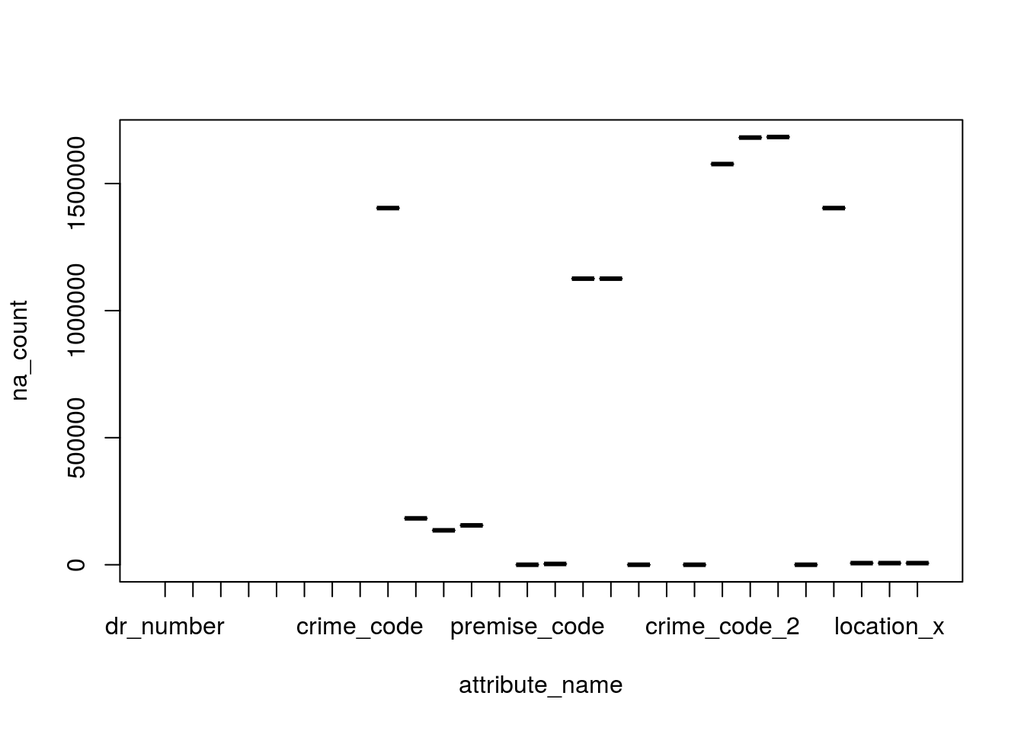

```r
# Creamos la nueva variable con un count
na_count <- do.call(rbind, lapply(colnames(crime_data), function(x) {return(data.frame(x, sum(is.na(crime_data[[x]]))))}))

# Cambiamos el nombre de las variables en el dataset
colnames(na_count) <- c('attribute_name', 'na_count')
# na_count$attribute_name <- as.character(na_count$attribute_name)

# Nos quedamos con los distintos de cero
na_count <- na_count[na_count$na_count != 0,]

# Lo vemos en gráfico
plot(na_count)
```

## Nuevas variables

```r
# Creamos una variable con el mes del crimen
crime_data$crime_month <- as.factor(substr(as.character(crime_data$date_occurred), 1, 2))

# Vemos en tabla
table(crime_data$crime_month, useNA = 'ifany')
```

```
##
##     01     02     03     04     05     06     07     08     09     10
## 160757 127346 138530 135394 141384 139076 143685 144028 138439 143885
##     11     12
## 132921 137864
```

Cambiamos los valores tipo fecha a formato as.Date

```r
crime_data$date_reported <- as.Date(as.character(crime_data$date_reported), '%m/%d/%Y')
crime_data$date_occurred <- as.Date(as.character(crime_data$date_occurred), '%m/%d/%Y')
```

Ordenamos por fecha

```r
crime_data <- crime_data[order(crime_data$date_occurred), ]
```

Generamos algunas columnas

Año

```r
# Con lubridate
# crime_data$crime_year  <- year(crime_data$date_occurred)
crime_data$crime_year  <- as.factor(substr(as.character(crime_data$date_occurred), 1, 4))
table(crime_data$crime_year, useNA = 'ifany')
```

```
##
##   2010   2011   2012   2013   2014   2015   2016   2017   2018
## 208631 200251 200888 191887 194632 214212 223690 227931  21187
```

Mes

```r
# Mes
# Con lubridate
# crime_data$crime_month <- month(crime_data$date_occurred, label = TRUE)
crime_data$crime_month <- as.factor(substr(as.character(crime_data$date_occurred), 6, 7))
table(crime_data$crime_month, useNA = 'ifany')
```

```
##
##     01     02     03     04     05     06     07     08     09     10
## 160757 127346 138530 135394 141384 139076 143685 144028 138439 143885
##     11     12
## 132921 137864
```

Semana

```r
crime_data$crime_week  <- week(crime_data$date_occurred)
table(crime_data$crime_week, useNA = 'ifany')
```

[output not shown]

Convertimos el tiempo con el paquete **chron**

```r
crime_data$crime_time  <- times(substr(as.POSIXct(sprintf("%04.0f", crime_data$time_occurred), origin = '1970-01-01', "Asia/Calcutta", format='%H%M'), 12, 19))
```

Creamos una variable minuto

```r
crime_data$crime_minute  <- (crime_data$time_occurred %/% 100)*60 + (crime_data$time_occurred %% 100)*100
table(crime_data$crime_minute, useNA = 'ifany')
```

```
##
##    60   100   120   160   180   200   220   240   260   280   300   320
## 20680 29008 17806    16 13081    77    16  9022    29    22  7879    19
##   340   360   380   400   420   440   460   480   500   520   540   560
##     9 12866    26    52 17138    28    34 41277  8995    45 31455   800
##   580   600   620   640   660   680   700   720   740   760   780   800
##    37 34706   789    40 27988   592    86 93519   487    70 30837   432
##   820   840   860   880   900   920   940   960   980  1000  1020  1040
##   155 34841   421    68 39481   550    74 39456   749  3365 44112   795
##  1060  1080  1100  1120  1140  1160  1180  1200  1220  1240  1260  1280
##  1836 50136   983  1577 44675  1100  1205 46920  1355   961 43079  1211
##  1300  1320  1340  1360  1380  1400  1420  1440  1460  1480  1500  1520
##   873 44105  1343   812 34900  1369  1286   122  1346  1639  3755  1305
##  1540  1560  1580  1600  1620  1640  1660  1680  1700  1720  1740  1760
##  1633  2590  1359  1706  2436  1302  2049  1828  1456  2450  1379  1345
```

[output cut: 46 more lines]

Establecemos algunas franjas horarias

```r
crime_data$crime_time_interval  <- cut(crime_data$crime_time, breaks = times(c('00:00:00', '05:00:00', '09:00:00', '13:00:00', '17:00:00', '21:00:00', '23:59:00')), labels = c('Late_night', 'Early_morning', 'Late_morning', 'Early_afternoon', 'Late_afternoon', 'Evening'), include.lowest = TRUE)
table(crime_data$crime_time_interval, useNA = 'ifany')
```

```
##
##      Late_night   Early_morning    Late_morning Early_afternoon
##          218525          186980          336565          340978
##  Late_afternoon         Evening
##          385880          214381
```

```r
# crime_data$crime_time <- as.factor(crime_data$crime_time)
crime_data$crime_time <- NULL
```

Día de la semana

```r
crime_data$occurred_week_day <- factor(weekdays(crime_data$date_occurred),
                                       levels = c("lunes", "martes",
                                                  "miércoles", "jueves",
                                                  "viernes", "sábado",
                                                  "domingo"))
table(crime_data$occurred_week_day, useNA = 'ifany')
```

```
##
##     lunes    martes miércoles    jueves   viernes    sábado   domingo
##    239881    235817    238315    236632    259729    242043    230892
```

Tiempo de retraso a la hora de denunciar

```r
crime_data$delay_reported <- crime_data$date_reported - crime_data$date_occurred
crime_data$delay_reported <- as.numeric(crime_data$delay_reported)
```

```r
# En esta parte se crean nuevas variables a partir de la suma y de la media
# No se ejecuta al tener eval=FALSE
week_day_occurred_sum   <- aggregate(date_occurred ~ occurred_week_day,
                                     data = crime_data, "sum")
week_day_occurred_mean  <- aggregate(date_occurred ~ occured_week_day,
                                     data = crime_data, "mean")

all_sum   <- aggregate(target ~ date_occurred + occurred_week_day,
                       data = train, "sum")
all_mean  <- aggregate(target ~ date_occurred + occured_week_day,
                       data = train, "mean")

plot(all_mean$date_occurred, all_mean$target)
```

Otro **summary()**

```r
summary(crime_data)
```

```
##    dr_number         date_reported        date_occurred
##  Min.   :      210   Min.   :2010-01-01   Min.   :2010-01-01
##  1st Qu.:120315238   1st Qu.:2012-02-11   1st Qu.:2012-01-21
##  Median :140620602   Median :2014-04-13   Median :2014-03-21
##  Mean   :138030952   Mean   :2014-03-08   Mean   :2014-02-19
##  3rd Qu.:160624731   3rd Qu.:2016-04-13   3rd Qu.:2016-03-28
##  Max.   :910220366   Max.   :2018-02-10   Max.   :2018-02-10
##
##  time_occurred     area_id            area_name       reporting_district
##  Min.   :   1   Min.   : 1.00   77th Street: 117154   Min.   : 100
##  1st Qu.: 930   1st Qu.: 6.00   Southwest  : 108517   1st Qu.: 645
##  Median :1430   Median :12.00   N Hollywood:  91554   Median :1204
##  Mean   :1364   Mean   :11.14   Pacific    :  88964   Mean   :1161
##  3rd Qu.:1900   3rd Qu.:16.00   Southeast  :  88578   3rd Qu.:1675
##  Max.   :2359   Max.   :21.00   Mission    :  84802   Max.   :2198
##                                 (Other)    :1103740
##    crime_code                        crime_code_description
##  Min.   :110.0   BROADWAY                       :   4923
##  1st Qu.:330.0   FIGUEROA                       :   2969
##  Median :440.0   VERMONT                      AV:   2953
##  Mean   :506.8   SAN PEDRO                      :   2821
##  3rd Qu.:626.0   WESTERN                      AV:   2821
##  Max.   :956.0   (Other)                        : 263330
##                  NA's                           :1403492
##    mo_codes           victim_age     victim_sex
##  Length:1683309     Min.   :10.00    F   :715645
##  Class :character   1st Qu.:23.00    H   :    56
##  Mode  :character   Median :34.00    M   :784098
##                     Mean   :35.97    X   : 28441
##                     3rd Qu.:48.00    NA's:155069
##                     Max.   :99.00
##                     NA's   :135446
##                 victim_descent    premise_code
##  Hispanic-Latin-Mexican:582840   Min.   :101
##  White                 :414424   1st Qu.:102
##  Black                 :269782   Median :210
##  Unknown               :202118   Mean   :312
##  Other                 :162664   3rd Qu.:501
##   Other_Asian          : 39648   Max.   :971
##  (Other)               : 11833   NA's   :97
```

[output cut: 57 more lines]

```
##  Min.   :  60   Late_night     :218525   lunes    :239881
##  1st Qu.: 840   Early_morning  :186980   martes   :235817
##  Median :1400   Late_morning   :336565   miércoles:238315
##  Mean   :2382   Early_afternoon:340978   jueves   :236632
##  3rd Qu.:3960   Late_afternoon :385880   viernes  :259729
##  Max.   :7280   Evening        :214381   sábado   :242043
##                                          domingo  :230892
##  delay_reported
##  Min.   :   0.00
##  1st Qu.:   0.00
##  Median :   1.00
##  Mean   :  16.76
##  3rd Qu.:   2.00
##  Max.   :2941.00
##
```

## Modelado

Estado del informe del crimen. Vemos una tabla con las opciones

```r
table(crime_data$status_description, useNA = 'ifany')
```

```
##
## Adult Arrest  Adult Other  Invest Cont   Juv Arrest    Juv Other
##       172666       190613      1302599        13246         4154
##          UNK
##           31
```

Creamos una variable para predecir, **target**

```r
# Empezamos con todos los valores como 'Closed'
crime_data$target <- 'Closed'

# Y ahora los que crime_data$status_description=='Invest Cont' pasan a 'Open'
crime_data$target[crime_data$status_description=='Invest Cont'] <- 'Open'

# Una tabla
table(crime_data$target, useNA = 'ifany')
```

```
##
##  Closed    Open
##  380710 1302599
```

```r
# Y pasamos a factor
crime_data$target <- as.factor(crime_data$target)
```

## Crear training y validating

```r
# training hasta el año 2016
training   <- crime_data[crime_data$date_occurred<as.Date('2017-01-01'), ]

# Validating el año 2017
validating <- crime_data[(crime_data$date_occurred>as.Date('2016-12-31') & crime_data$date_occurred<as.Date('2018-01-01')), ]

# testing el año 2018
testing    <- crime_data[crime_data$date_occurred>as.Date('2017-12-31'), ]
```

## Iniciar H2O en local

```r
# Iniciamos con todos los cores posibles y la memoria de 32G (si hay menos se
# autoregula)
h2o.init(nthreads=-1, max_mem_size="32G")
```

```
##  Connection successful!
##
## R is connected to the H2O cluster:
##     H2O cluster uptime:         45 minutes 43 seconds
##     H2O cluster version:        3.16.0.2
##     H2O cluster version age:    3 months and 12 days !!!
##     H2O cluster name:           H2O_started_from_R_enero_ahz489
##     H2O cluster total nodes:    1
##     H2O cluster total memory:   6.35 GB
##     H2O cluster total cores:    4
##     H2O cluster allowed cores:  4
##     H2O cluster healthy:        TRUE
##     H2O Connection ip:          localhost
##     H2O Connection port:        54321
##     H2O Connection proxy:       NA
##     H2O Internal Security:      FALSE
##     H2O API Extensions:         XGBoost, Algos, AutoML, Core V3, Core V4
##     R Version:                  R version 3.4.3 (2017-11-30)
```

```r
# Si queremos conectar a un cluster que ya está funcionando
# h2o.init(ip="mycluster", port=55555)
```

Pasamos los objetos a H2O y les damos nombre para poder identificarlos

```r
training_h2o   <- as.h2o(training,
                         destination_frame = "training")
validating_h2o <- as.h2o(validating,
                         destination_frame = "validating")
testing_h2o    <- as.h2o(testing,
                         destination_frame = "testing")
```

### AutoML

Tras estos pasos en los que someramente hemos hecho ETL, tratamiento de NAs y algunas variables nuevas, pasamos a la parte de autoML

```r
# La columna target
y <- "target"

# Las otras variables a usar, primero todas menos el target
x <- setdiff(names(training), y)

# Ahora quitamos también: 'dr_number', 'status_code', 'status_description'
x <- x[!(x %in% c('dr_number', 'status_code', 'status_description'))]
```

Llamamos a automl. Solo le decimos los datos, la columna target, que hay un dataset de train y uno de validación y cuantos minutos de ejecución

```r
tiempo_inicio <- Sys.time()
automl_models_h2o <- h2o.automl(
    x                 = x,
    y                 = y,
    training_frame    = training_h2o,
    validation_frame  = validating_h2o,
    # leaderboard_frame = test_h2o,
    max_runtime_secs  = 3600, # 180
    stopping_metric   = "AUTO")
print(Sys.time()-tiempo_inicio)
```

```
## Time difference of 1.099437 hours
```

Podemos ver lo que hace H2O en: http://localhost:54321/flow/index.html

Creamos un objeto con el mejor modelo

```r
automl_leader <- automl_models_h2o@leader
```

## Predicción

```r
# Pasamos el modelo y los datos nuevos
pred_testing <- as.data.frame(h2o.predict(automl_leader, newdata = testing_h2o))
```

[output not shown]

[output not shown]

Vemos el objeto de la predicción

```r
str(pred_testing)
```

```
## 'data.frame':    21187 obs. of  3 variables:
##  $ predict: Factor w/ 2 levels "Closed","Open": 2 2 2 2 2 2 2 2 2 2 ...
##  $ Closed : num  0.0531 0.0603 0.1482 0.0616 0.1985 ...
##  $ Open   : num  0.947 0.94 0.852 0.938 0.801 ...
```

Un resumen de la performance en el objeto de test

```r
h2o.performance(automl_leader, newdata = testing_h2o)
```

```
## H2OBinomialMetrics: stackedensemble
##
## MSE:  0.1189653
## RMSE:  0.3449135
## LogLoss:  0.3745473
## Mean Per-Class Error:  0.4982028
## AUC:  0.7885211
## Gini:  0.5770422
##
## Confusion Matrix (vertical: actual; across: predicted) for F1-optimal threshold:
##        Closed  Open    Error         Rate
## Closed      8  2095 0.996196   =2095/2103
## Open        4 19080 0.000210     =4/19084
## Totals     12 21175 0.099070  =2099/21187
##
## Maximum Metrics: Maximum metrics at their respective thresholds
##                         metric threshold    value idx
## 1                       max f1  0.089551 0.947863 397
## 2                       max f2  0.079476 0.978436 399
## 3                 max f0point5  0.393782 0.923999 290
## 4                 max accuracy  0.089551 0.900930 397
## 5                max precision  0.950663 1.000000   0
## 6                   max recall  0.079476 1.000000 399
## 7              max specificity  0.950663 1.000000   0
## 8             max absolute_mcc  0.708349 0.297129 162
## 9   max min_per_class_accuracy  0.731609 0.727532 151
## 10 max mean_per_class_accuracy  0.758218 0.731465 137
##
## Gains/Lift Table: Extract with `h2o.gainsLift(<model>, <data>)` or `h2o.gainsLift(<model>, valid=<T/F>, xval=<T/F>)`
```

```r
as.data.frame(automl_models_h2o@leaderboard)
```

```
##                                                model_id auc logloss
## 1    StackedEnsemble_AllModels_0_AutoML_20180313_122540  NA      NA
## 2 StackedEnsemble_BestOfFamily_0_AutoML_20180313_122540  NA      NA
## 3                          DRF_0_AutoML_20180313_122540  NA      NA
## 4                          XRT_0_AutoML_20180313_122540  NA      NA
## 5             GBM_grid_0_AutoML_20180313_122540_model_0  NA      NA
```

Y vemos el modelo

```r
automl_leader
```

```
## Model Details:
## ==============
##
## H2OBinomialModel: stackedensemble
## Model ID:  StackedEnsemble_AllModels_0_AutoML_20180313_122540
## NULL
##
##
## H2OBinomialMetrics: stackedensemble
## ** Reported on training data. **
##
## MSE:  0.07489115
## RMSE:  0.2736625
## LogLoss:  0.2651635
## Mean Per-Class Error:  0.1527908
## AUC:  0.9428592
## Gini:  0.8857184
##
## Confusion Matrix (vertical: actual; across: predicted) for F1-optimal threshold:
##        Closed    Open    Error             Rate
## Closed 245185   86336 0.260424    =86336/331521
## Open    49794 1052876 0.045158   =49794/1102670
## Totals 294979 1139212 0.094918  =136130/1434191
##
## Maximum Metrics: Maximum metrics at their respective thresholds
##                         metric threshold    value idx
## 1                       max f1  0.556156 0.939279 210
## 2                       max f2  0.301893 0.962042 296
## 3                 max f0point5  0.756018 0.939519 137
## 4                 max accuracy  0.583495 0.905195 201
## 5                max precision  0.952286 1.000000   0
## 6                   max recall  0.065308 1.000000 394
## 7              max specificity  0.952286 1.000000   0
## 8             max absolute_mcc  0.626318 0.727934 188
## 9   max min_per_class_accuracy  0.805609 0.869694 115
## 10 max mean_per_class_accuracy  0.766066 0.871189 133
##
## Gains/Lift Table: Extract with `h2o.gainsLift(<model>, <data>)` or `h2o.gainsLift(<model>, valid=<T/F>, xval=<T/F>)`
## H2OBinomialMetrics: stackedensemble
## ** Reported on validation data. **
```

[output cut: 44 more lines]

```
##
## Maximum Metrics: Maximum metrics at their respective thresholds
##                         metric threshold    value idx
## 1                       max f1  0.462545 0.899213 248
## 2                       max f2  0.141606 0.945331 367
## 3                 max f0point5  0.770436 0.897762 130
## 4                 max accuracy  0.525549 0.839002 226
## 5                max precision  0.951479 0.995525   0
## 6                   max recall  0.053853 1.000000 399
## 7              max specificity  0.951479 0.999937   0
## 8             max absolute_mcc  0.710315 0.536213 155
## 9   max min_per_class_accuracy  0.825580 0.791672 102
## 10 max mean_per_class_accuracy  0.830853 0.791855  99
##
## Gains/Lift Table: Extract with `h2o.gainsLift(<model>, <data>)` or `h2o.gainsLift(<model>, valid=<T/F>, xval=<T/F>)`
```

Matriz de confusión sobre datos de testing con el paquete **caret**

```r
confusion_matrix <- caret::confusionMatrix(pred_testing$predict, testing$target)
confusion_matrix
```

```
## Confusion Matrix and Statistics
##
##           Reference
## Prediction Closed  Open
##     Closed    592  1356
##     Open     1511 17728
##
##                Accuracy : 0.8647
##                  95% CI : (0.86, 0.8693)
##     No Information Rate : 0.9007
##     P-Value [Acc > NIR] : 1.000000
##
##                   Kappa : 0.2176
##  Mcnemar's Test P-Value : 0.004026
##
##             Sensitivity : 0.28150
##             Specificity : 0.92895
##          Pos Pred Value : 0.30390
##          Neg Pred Value : 0.92146
##              Prevalence : 0.09926
##          Detection Rate : 0.02794
##    Detection Prevalence : 0.09194
##       Balanced Accuracy : 0.60522
##
##        'Positive' Class : Closed
##
```

## Links

- [Crime Analysis Using H2O Autoencoders (Part 1)](https://dzone.com/articles/crime-analysis-using-h2o-autoencoders-part-1)
- [Crime Analysis Using H2O Autoencoders (Part 2)](https://dzone.com/articles/crime-analysis-using-h2o-autoencoders-part-2)
- [Crime Data from 2010 to Present](https://data.lacity.org/A-Safe-City/Crime-Data-from-2010-to-Present/y8tr-7khq)
- H2O: [Web]](https://www.h2o.ai/), [Blog](https://blog.h2o.ai/), [Documentación](http://docs.h2o.ai/h2o/latest-stable/index.html), [Tutoriales](http://docs.h2o.ai/h2o/latest-stable/index.html#tutorials), [Demos en R](https://github.com/h2oai/h2o-3/tree/master/h2o-r/demos) y [Canal de Youtube](https://www.youtube.com/channel/UCk6ONJlPzjw3DohAeMSgsng)